# Cantwell, Alaska solar irradiance trends

### Solar irradiance time series by model

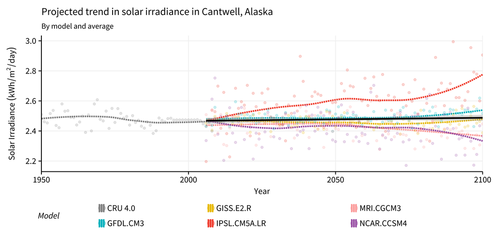

Figure 1 shows a historical baseline in gray and projected trends for each climate model using the other colors.

The colored trend lines and scatter plot of projected model outputs are faded to highlight the mean trend over the projected period. The estimated projected percent change in solar irradiance over the period 2006 - 2100 using the five climate models is 0.8%. This is approximately 0.1% change per decade during the period. These mean estimates are based on the linear regression in figure 1.

### Aggregate historical and projected period solar irradiance densities

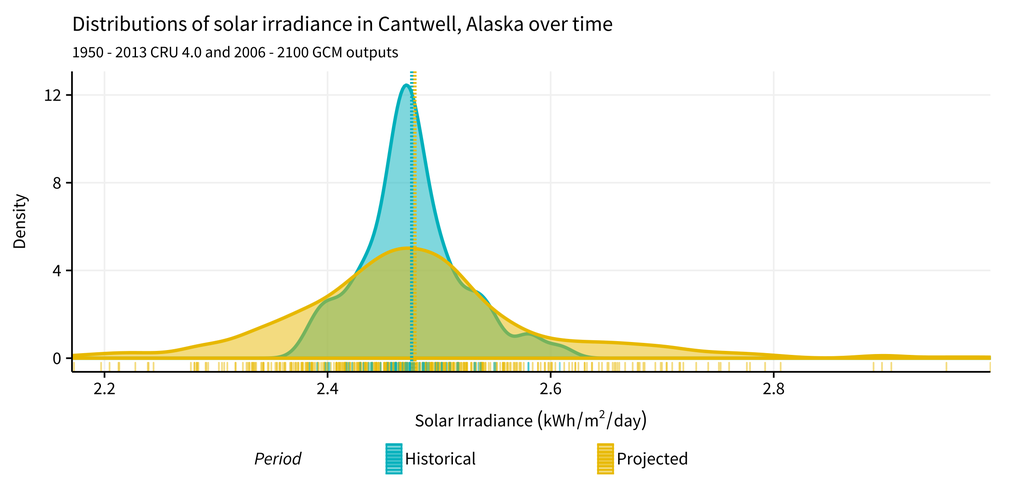

Figure 2 shows historical and projected distributions of annual solar irradiance over time.

The historical distribution pertains to solar irradiance observations based on downscaled CRU 4.0 data. The spread in projected outputs comes from pooling the five climate models.

Note that the latter distribution sample contains more observations than the former, using five models as well as a greater number of years.

### Solar irradiance box plots by model with select statistical tests

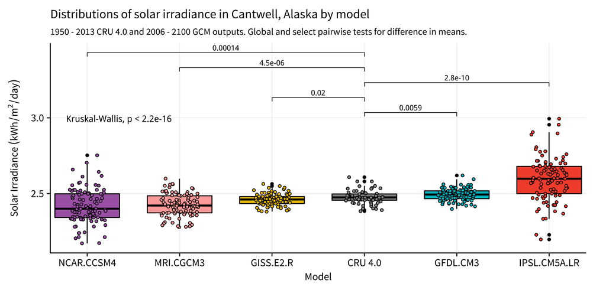

Another view of solar irradiance distributions is shown in figure 3, one for each model.

P-values for select statisticial tests for differences in group means of each climate model with respect to CRU 4.0 as the reference group are shown on the plot. The global Kruskal-Wallis p-value is also shown, though for these data sets its significance is not surprising.

Climate model projected period distirbution means for solar irradiance may differ significantly from the CRU 4.0 baseline in either direction and variability is greater across a set of climate models, as was seen in figure 2.

### Projected mean solar irradiance by model for select 30-year windows

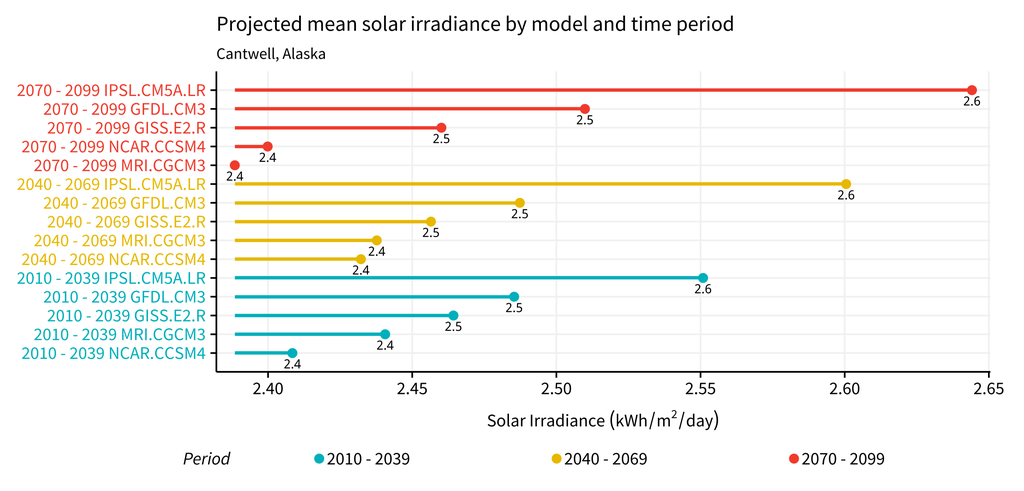

Figure 4 shows mean period solar irradiance for each climate model during each of three future 30-year windows.

Each period is broken out with a different color. Within periods, models are ranked by mean solar irradiance.